# Analyzing Weather Events Impacts on Public Health and Economy

## Synopsis

This analysis aims to analyze the effect of weather events on public health and the economy of the United States. Data is provided by the National Oceanic and Atmospheric Administration (NOAA) storm database. The analysis first cleans and groups listed NOAA “event types”, into event groups, then charts total fatalities, injuries, and the value of property and crop damage caused by the groups.

## Loading R Packages

```r
library(R.utils)
library(data.table)
library(dplyr)
```

```r
library(ggplot2)
library(grid)
library(gridExtra)
```

## Data Processing

Check to see if data file already exists in working directory. Then use `data.table::fread()` for fast reading of data file to `data` dataframe.

```r
if (!file.exists('stormdata.csv.bz2')) {
        download.file('https://d396qusza40orc.cloudfront.net/repdata%2Fdata%2FStormData.csv.bz2', 'stormdata.csv.bz2')
}

rawdata <- fread('stormdata.csv.bz2')
```

Check structure of `data`.

```r
str(rawdata)
```

```
## Classes 'data.table' and 'data.frame':   902297 obs. of  37 variables:
##  $ STATE__   : num  1 1 1 1 1 1 1 1 1 1 ...
##  $ BGN_DATE  : chr  "4/18/1950 0:00:00" "4/18/1950 0:00:00" "2/20/1951 0:00:00" "6/8/1951 0:00:00" ...
##  $ BGN_TIME  : chr  "0130" "0145" "1600" "0900" ...
##  $ TIME_ZONE : chr  "CST" "CST" "CST" "CST" ...
##  $ COUNTY    : num  97 3 57 89 43 77 9 123 125 57 ...
##  $ COUNTYNAME: chr  "MOBILE" "BALDWIN" "FAYETTE" "MADISON" ...
##  $ STATE     : chr  "AL" "AL" "AL" "AL" ...
##  $ EVTYPE    : chr  "TORNADO" "TORNADO" "TORNADO" "TORNADO" ...
##  $ BGN_RANGE : num  0 0 0 0 0 0 0 0 0 0 ...
##  $ BGN_AZI   : chr  "" "" "" "" ...
##  $ BGN_LOCATI: chr  "" "" "" "" ...
##  $ END_DATE  : chr  "" "" "" "" ...
##  $ END_TIME  : chr  "" "" "" "" ...
##  $ COUNTY_END: num  0 0 0 0 0 0 0 0 0 0 ...
```

[output cut: 24 more lines]

For purposes of this project, `EVTYPE`, `FATALITIES`, `INJURIES`, `PROPDMG`, `PROPDMGEXP`, `CROPDMG`, and `CROPDMGEXP` columns are extracted to new dataframe `data` using `dplyr::select()`

```r
data <- select(rawdata, EVTYPE, FATALITIES, INJURIES, PROPDMG, PROPDMGEXP, CROPDMG, CROPDMGEXP)
```

Check for any `NA` values by summing incomplete cases in `data`.

```r
incompletecases <- sum(!complete.cases(data))
```

Thus there are 0 incomplete cases; ie, no need to remove or impute `NA`s.

### Cleaning Event Types

Take a table of how many observations of each `EVTYPE` there are in decreasing order.

```r
# since the table is long, the markdown will just print the 30 highest occurring `EVTYPE`s
head(sort(table(data$EVTYPE), decreasing = TRUE), 30)
```

```
##
##                     HAIL                TSTM WIND        THUNDERSTORM WIND
##                   288661                   219940                    82563
##                  TORNADO              FLASH FLOOD                    FLOOD
##                    60652                    54277                    25326
##       THUNDERSTORM WINDS                HIGH WIND                LIGHTNING
##                    20843                    20212                    15754
##               HEAVY SNOW               HEAVY RAIN             WINTER STORM
##                    15708                    11723                    11433
##           WINTER WEATHER             FUNNEL CLOUD         MARINE TSTM WIND
##                     7026                     6839                     6175
## MARINE THUNDERSTORM WIND               WATERSPOUT              STRONG WIND
##                     5812                     3796                     3566
##     URBAN/SML STREAM FLD                 WILDFIRE                 BLIZZARD
##                     3392                     2761                     2719
##                  DROUGHT                ICE STORM           EXCESSIVE HEAT
##                     2488                     2006                     1678
##               HIGH WINDS         WILD/FOREST FIRE             FROST/FREEZE
##                     1533                     1457                     1342
##                DENSE FOG       WINTER WEATHER/MIX           TSTM WIND/HAIL
##                     1293                     1104                     1028
```

```r
# add new column for groups, default to OTHER first

data <- mutate(data, group = 'OTHER')

data$group[grep('HAIL', data$EVTYPE, ignore.case = TRUE)] <- 'HAIL'
data$group[grep('WIND|FUNNEL', data$EVTYPE, ignore.case = TRUE)] <- 'WIND'
data$group[grep('TORNADO|WATERSPOUT', data$EVTYPE, ignore.case = TRUE)] <- 'TORNADO'
data$group[grep('FLOOD|FLD', data$EVTYPE, ignore.case = TRUE)] <- 'FLOOD'
data$group[grep('SNOW', data$EVTYPE, ignore.case = TRUE)] <- 'SNOW'
data$group[grep('RAIN', data$EVTYPE, ignore.case = TRUE)] <- 'RAIN'
data$group[grep('STORM|LIGHTNING|SURGE', data$EVTYPE, ignore.case = TRUE)] <- 'STORM'
data$group[grep('FIRE', data$EVTYPE, ignore.case = TRUE)] <- 'FIRE'
data$group[grep('HURRICANE|TYPHOON', data$EVTYPE, ignore.case = TRUE)] <- 'HURRICANE'
data$group[grep('COLD|ICE|FROST|ICY|FREEZ', data$EVTYPE, ignore.case = TRUE)] <- 'COLD'
data$group[grep('HEAT|HOT|WARM|DRY|DROUGHT', data$EVTYPE, ignore.case = TRUE)] <- 'HEAT'
```

Take a table of observations in each group.

```r
table(data$group)
```

```
##
##      COLD      FIRE     FLOOD      HAIL      HEAT HURRICANE     OTHER      RAIN
##      6604      4240     86075    289268      5777       299     16894     11900
##      SNOW     STORM   TORNADO      WIND
##     17563    138357     64546    260774
```

### Cleaning Damage Columns

The data has `PROPDMGEXP` and `CROPDMGEXP`, which provide the exponent values of `PROPDMG` and `CROPDMG`.

```r
unique(data$PROPDMGEXP)
```

```
##  [1] "K" "M" ""  "B" "m" "+" "0" "5" "6" "?" "4" "2" "3" "h" "7" "H" "-" "1" "8"
```

```r
unique(data$CROPDMGEXP)
```

```
## [1] ""  "M" "K" "m" "B" "?" "0" "k" "2"
```

Letters correspond to the metric prefixes, with the assumptions of

- “B” represents billions.
- “m” is treated the same as “M”
- “K” is treated the same as “k”
- “H” is treated the same as “h”
- Empty values, “+”, “?”, and “-” are treated as “0”

`PROPDMGUSD` and `CROPDMGUSD` will be `PROPDMG` and `CROPDMG` reformatted to be in dollars.

```r
tidydata <- data %>%
        mutate(PROPDMGUSD = case_when(
                PROPDMGEXP == "K" ~ PROPDMG * 1e3,
                PROPDMGEXP == "M" ~ PROPDMG * 1e6,
                PROPDMGEXP == ""  ~ PROPDMG,
                PROPDMGEXP == "B" ~ PROPDMG * 1e9,
                PROPDMGEXP == "m" ~ PROPDMG * 1e6,
                PROPDMGEXP == "+" ~ PROPDMG,
                PROPDMGEXP == "0" ~ PROPDMG,
                PROPDMGEXP == "5" ~ PROPDMG * 1e5,
                PROPDMGEXP == "6" ~ PROPDMG * 1e6,
                PROPDMGEXP == "?" ~ PROPDMG,
                PROPDMGEXP == "4" ~ PROPDMG * 1e4,
                PROPDMGEXP == "2" ~ PROPDMG * 1e2,
                PROPDMGEXP == "3" ~ PROPDMG * 1e3,
                PROPDMGEXP == "h" ~ PROPDMG * 1e2,
                PROPDMGEXP == "7" ~ PROPDMG * 1e7,
                PROPDMGEXP == "H" ~ PROPDMG * 1e2,
                PROPDMGEXP == "-" ~ PROPDMG,
                PROPDMGEXP == "1" ~ PROPDMG * 10,
                PROPDMGEXP == "8" ~ PROPDMG * 1e8
        )) %>%
        mutate(CROPDMGUSD = case_when(
                CROPDMGEXP == ""  ~ CROPDMG,
                CROPDMGEXP == "M" ~ CROPDMG * 1e6,
                CROPDMGEXP == "K" ~ CROPDMG * 1e3,
                CROPDMGEXP == "m" ~ CROPDMG * 1e6,
                CROPDMGEXP == "B" ~ CROPDMG * 1e9,
                CROPDMGEXP == "?" ~ CROPDMG,
                CROPDMGEXP == "0" ~ CROPDMG,
                CROPDMGEXP == "k" ~ CROPDMG * 1e3,
                CROPDMGEXP == "2" ~ CROPDMG * 1e2
        ))
```

### Summarizing Data

Summarise `tidydata` with the totals of `FATALITIES`, `INJURIES`, `PROPDMGUSD`, `CROPDMGUSD` by `group`. Additional columns `HEALTH` and `TOTALDMG` combine total `FATALITIES` and `INJURIES`, and `PROPDMG` and `CROPDMG`.

```r
tidydata <- group_by(tidydata, group)
sumdata <- tidydata %>% summarise(FATALITIES = sum(FATALITIES),
                                  INJURIES = sum(INJURIES),
                                  PROPDMG = sum(PROPDMGUSD),
                                  CROPDMG = sum(CROPDMGUSD)) %>%
        mutate(HEALTH = FATALITIES + INJURIES, TOTALDMG = PROPDMG + CROPDMG) %>%
        arrange(desc(HEALTH))
```

## Results

### Question 1

Across the United States, which types of events are most harmful with respect to population health?

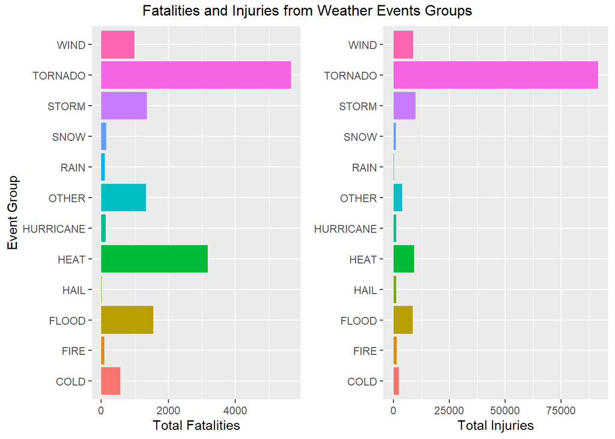

```r
fatalg <- ggplot(sumdata, aes(x = group, y = FATALITIES)) +
        geom_bar(stat = 'identity', aes(fill = group)) +
        coord_flip() +
        xlab("Event Group") +
        ylab("Total Fatalities") +
        theme(legend.position = "none")
injuryg <- ggplot(sumdata, aes(x = group, y = INJURIES)) +
        geom_bar(stat = 'identity', aes(fill = group)) +
        coord_flip() +
        ylab("Total Injuries") +
        theme(legend.position = "none", axis.title.y=element_blank())
grid.arrange(fatalg, injuryg, ncol=2, nrow=1,
     top = textGrob("Fatalities and Injuries from Weather Events Groups"))
```

From the plot, the event group “TORNADO” has the largest impact on public health, both in fatalities and injuries.

```r
knitr::kable(sumdata[1,c(1:3,6)], format = 'markdown')
```

| group | FATALITIES | INJURIES | HEALTH |
| --- | --- | --- | --- |
| TORNADO | 5664 | 91436 | 97100 |

### Question 2

Across the United States, which types of events have the greatest economic consequences?

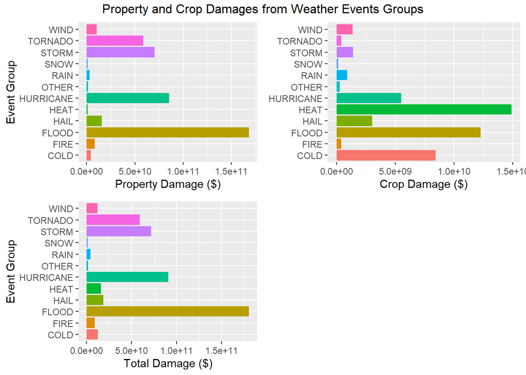

```r
propg <- ggplot(sumdata, aes(x = group, y = PROPDMG)) +
        geom_bar(stat = 'identity', aes(fill = group)) +
        coord_flip() +
        xlab("Event Group") +
        ylab("Property Damage ($)") +
        theme(legend.position = "none")
cropg <- ggplot(sumdata, aes(x = group, y = CROPDMG)) +
        geom_bar(stat = 'identity', aes(fill = group)) +
        coord_flip() +
        ylab("Crop Damage ($)") +
        theme(legend.position = "none", axis.title.y=element_blank())
totalg <- ggplot(sumdata, aes(x = group, y = TOTALDMG)) +
        geom_bar(stat = 'identity', aes(fill = group)) +
        coord_flip() +
        xlab("Event Group") +
        ylab("Total Damage ($)") +
        theme(legend.position = "none")
grid.arrange(propg, cropg, totalg, ncol=2, nrow=2,
     top = textGrob("Property and Crop Damages from Weather Events Groups"))
```

From the plot, the event group “FLOOD” has the largest impact on property damage and total damage, and “HEAT” has the largest impact on crop damage.

```r
knitr::kable(sumdata[c(4,2),c(1,4,5,7)], format = 'markdown')
```

| group | PROPDMG | CROPDMG | TOTALDMG |
| --- | --- | --- | --- |
| FLOOD | 168242211483 | 12270394200 | 180512605683 |
| HEAT | 1073164350 | 14877060280 | 15950224630 |